# Project 1

Caleb Hallinan

2023-09-16

## Read in Data

Read in Data from TidyTuesday

```r
# using here package for relative path
# NOTE: I downloaded jhustatcomputing2023 repository to local machine :)
chocolate = readRDS(here::here("data", "chocolate.RDS"))
# glimpse(chocolate)
```

## Part 1: Explore Data

1. Make a histogram of the rating scores to visualize the overall distribution of scores. Change the number of bins from the default to 10, 15, 20, and 25. Pick on the one that you think looks the best. Explain what the difference is when you change the number of bins and explain why you picked the one you did.

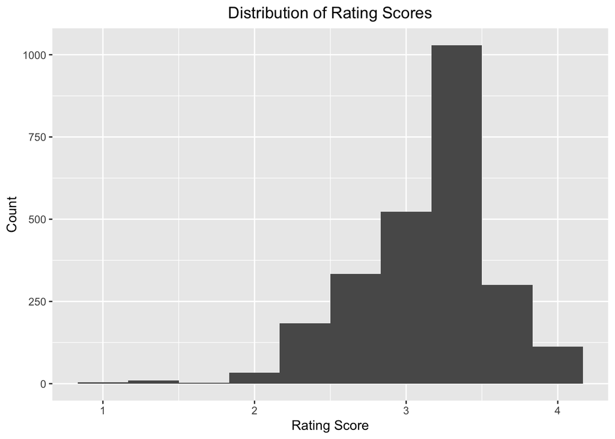

```r
# use ggplot for histogram
ggplot(chocolate, aes(x=rating)) + geom_histogram(bins=10) + labs(title="Distribution of Rating Scores", x = "Rating Score", y = "Count") +
  theme(plot.title = element_text(hjust = 0.5))
```

I believe 10 bins looks the best which is why I choose to output it. When testing other bins, there seemed to be many gaps between them which made it harder to see the overall distribution of rating score. However, when using 10 bins it removes any gaps between the bins and the overall shape of the distribution is clear. I would likely do further testing on the distribution to confirm it is normal.

2. Consider the countries where the beans originated from. How many reviews come from each country of bean origin?

```r
# review per country
chocolate %>%
    group_by(country_of_bean_origin) %>%
    summarise(reveiw_totals = length(country_of_bean_origin))
```

```
## # A tibble: 62 × 2
##    country_of_bean_origin reveiw_totals
##    <chr>                          <int>
##  1 Australia                          3
##  2 Belize                            76
##  3 Blend                            156
##  4 Bolivia                           80
##  5 Brazil                            78
##  6 Burma                              1
##  7 Cameroon                           3
##  8 China                              1
##  9 Colombia                          79
## 10 Congo                             11
## # ℹ 52 more rows
```

I only printed out this top of the tibble, but this code gets the total reviews from each country. It seems the U.S.A. is not a popular country for producing beans at 33 compared to others (ex. Dominican Republic at 226).

3. What is average rating scores from reviews of chocolate bars that have Ecuador as country_of_bean_origin in this dataset? For this same set of reviews, also calculate (1) the total number of reviews and (2) the standard deviation of the rating scores. Your answer should be a new data frame with these three summary statistics in three columns. Label the name of these columns mean, sd, and total.

```r
# get stats
ecuador_stats = chocolate[chocolate$country_of_bean_origin == "Ecuador",] %>%
    group_by(country_of_bean_origin) %>% # NOTE: Added this to print Ecuador in table
    summarise(mean = mean(rating), sd = sd(rating), total = length(rating))
# print new data frame
ecuador_stats
```

```
## # A tibble: 1 × 4
##   country_of_bean_origin  mean    sd total
##   <chr>                  <dbl> <dbl> <int>
## 1 Ecuador                 3.16 0.512   219
```

The summary statistics for Ecuador as a country of bean origin are as follows: Mean = 3.16, Standard Deviation = 0.512, and Total Reviews = 219

4. Which country makes the best chocolate (or has the highest ratings on average) with beans from Ecuador?

```r
# company with best chocolate from Ecuador
chocolate[chocolate$country_of_bean_origin == "Ecuador",] %>%
    group_by(country_of_bean_origin, company_location) %>%
    summarise(mean = mean(rating)) %>%
    slice_max(mean)
```

```
## # A tibble: 1 × 3
## # Groups:   country_of_bean_origin [1]
##   country_of_bean_origin company_location  mean
##   <chr>                  <chr>            <dbl>
## 1 Ecuador                Australia         3.81
```

The company that makes the best chocolate with beans from Ecuador based on rating is Australia at 3.8125

5. Calculate the average rating across all country of origins for beans. Which top 3 countries have the highest ratings on average?

```r
# top 3 countries
chocolate %>%
    group_by(country_of_bean_origin) %>%
    summarise(mean = mean(rating)) %>%
    slice_max(mean, n=3)
```

```
## # A tibble: 3 × 2
##   country_of_bean_origin  mean
##   <chr>                  <dbl>
## 1 Tobago                  3.62
## 2 China                   3.5
## 3 Sao Tome & Principe     3.5
```

The top 3 countries with the highest ratings on average are Tobago, China, and Sao Tome & Principe.

6. Following up on the previous problem, now remove any countries of bean origins that have less than 10 chocolate bar reviews. Now, which top 3 countries have the highest ratings on average?

```r
# top 3 countries
chocolate %>%
    group_by(country_of_bean_origin) %>%
    summarise(mean = mean(rating), num_reviews = length(country_of_bean_origin)) %>%
    filter(., num_reviews >= 10) %>%
    slice_max(mean, n=3)
```

```
## # A tibble: 3 × 3
##   country_of_bean_origin  mean num_reviews
##   <chr>                  <dbl>       <int>
## 1 Solomon Islands         3.45          10
## 2 Congo                   3.32          11
## 3 Cuba                    3.29          12
```

After removing countries with less than 10 reviews, the top 3 countries with the highest ratings on average are Solomon Islands, Congo, and Cuba. NOTE: I used 10 or more.. so less than and NOT equal to 10.

7. For this last part, let’s explore the relationship between percent chocolate and ratings. Use the functions in dplyr, tidyr, and lubridate to perform the following steps to the chocolate dataset:
   1. Identify the countries of bean origin with at least 50 reviews. Remove reviews from countries are not in this list.
   2. Using the variable describing the chocolate percentage for each review, create a new column that groups chocolate percentages into one of four groups: (i) <60%, (ii) >=60 to <70%, (iii) >=70 to <90%, and (iii) >=90% (Hint check out the substr() function in base R and the case_when() function from dplyr – see example below).
   3. Using the new column described in #2, re-order the factor levels (if needed) to be starting with the smallest percentage group and increasing to the largest percentage group (Hint check out the fct_relevel() function from forcats).
   4. For each country, make a set of four side-by-side boxplots plotting the groups on the x-axis and the ratings on the y-axis. These plots should be faceted by country.

On average, which category of chocolate percentage is most highly rated? Do these countries mostly agree or are there disagreements?

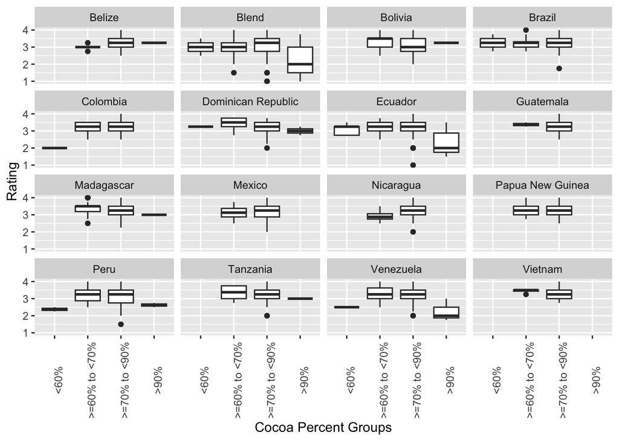

```r
# 1. countries with less than 50 reviews
gt50 = chocolate %>%
    group_by(country_of_bean_origin) %>%
    summarise(review_total = length(country_of_bean_origin)) %>%
    filter(., review_total >= 50)
# subset only countries I want
chocolate_gt50 = chocolate[chocolate$country_of_bean_origin %in% gt50$country_of_bean_origin,]
# print to show df
# chocolate_gt50

# replace
chocolate_gt50 = chocolate[chocolate$country_of_bean_origin %in% gt50$country_of_bean_origin,]


# 2. new column
chocolate_gt50 = chocolate_gt50 %>%
    mutate(
        cocoa_percent_group = case_when(
            as.numeric(str_replace_all(cocoa_percent, "%", "")) < 60 ~ "<60%",
            as.numeric(str_replace_all(cocoa_percent, "%", "")) >= 60 &
              as.numeric(str_replace_all(cocoa_percent, "%", "")) < 70 ~ ">=60% to <70%",
            as.numeric(str_replace_all(cocoa_percent, "%", "")) >= 70 &
              as.numeric(str_replace_all(cocoa_percent, "%", "")) < 90 ~ ">=70% to <90%",
            as.numeric(str_replace_all(cocoa_percent, "%", "")) >= 90 ~ ">90%"
        )
    )

# 3. factor relevel
chocolate_gt50$cocoa_percent_group = factor(chocolate_gt50$cocoa_percent_group)
# do not need to refactor levels!

# 4. boxplots
ggplot(chocolate_gt50, aes(x=cocoa_percent_group, y = rating)) +
    geom_boxplot() +
    facet_wrap(. ~ country_of_bean_origin) +
  labs(y = "Rating", x = "Cocoa Percent Groups") +
  theme(axis.text.x = element_text(angle=90))
```

Using the boxplots, it seems that on average >=60% to <70% of chocolate percentage is most highly rated. However, >=70% to <90% might be very close to the average. Surprisingly, 90% chocolate percentage is typically rating lower than the middle classes. Based on the overall plot, it appears that most countries agree with chocolate percentage ratings!

Note: I did a bit of adding to this plot (x,y labs and ticks 90) but am curious what would make this look the best? Just a lot of graphs on one figure so don’t know how I would want this presented.

## Part 2: Join two datasets together

1. Use this dataset it to create a new column called continent in our chocolate dataset that contains the continent name for each review where the country of bean origin is.

```r
# load in gapminder package
library(gapminder)

# subset gapminder
gapminder_sub = gapminder[,c("country", "continent")]
# rename columns
colnames(gapminder_sub) = c("country_of_bean_origin", "continent")

# add new column
by = join_by(country_of_bean_origin == country)
chocolate_continent = left_join(x = chocolate, y = unique(gapminder[,c("country", "continent")]), by)
# get rid of NA's by adding correct place

# correct NA's
chocolate_continent[chocolate_continent$country_of_bean_origin == "Fiji",]$continent = "Oceania"
chocolate_continent[chocolate_continent$country_of_bean_origin == "Burma",]$continent = "Asia"
chocolate_continent[chocolate_continent$country_of_bean_origin == "Papua New Guinea",]$continent = "Oceania"
chocolate_continent[chocolate_continent$country_of_bean_origin == "Vanuatu",]$continent = "Oceania"
chocolate_continent[chocolate_continent$country_of_bean_origin == "Trinidad",]$continent = "Americas"
chocolate_continent[chocolate_continent$country_of_bean_origin == "Sao Tome",]$continent = "Africa"
chocolate_continent[chocolate_continent$country_of_bean_origin == "Belize",]$continent = "Americas"
chocolate_continent[chocolate_continent$country_of_bean_origin == "Grenada",]$continent = "Americas"
# assigning blend to americas here for now, delete it later but wanted everything to be in order :)
chocolate_continent[chocolate_continent$country_of_bean_origin == "Blend",]$continent = "Americas"
chocolate_continent[chocolate_continent$country_of_bean_origin == "Solomon Islands",]$continent = "Oceania"
chocolate_continent[chocolate_continent$country_of_bean_origin == "Congo",]$continent = "Africa"
chocolate_continent[chocolate_continent$country_of_bean_origin == "Ivory Coast",]$continent = "Africa"
chocolate_continent[chocolate_continent$country_of_bean_origin == "Martinique",]$continent = "Americas"
chocolate_continent[chocolate_continent$country_of_bean_origin == "St. Lucia",]$continent = "Americas"
chocolate_continent[chocolate_continent$country_of_bean_origin == "U.S.A.",]$continent = "Americas"
chocolate_continent[chocolate_continent$country_of_bean_origin == "St.Vincent-Grenadines",]$continent = "Americas"
chocolate_continent[chocolate_continent$country_of_bean_origin == "Tobago",]$continent = "Americas"
chocolate_continent[chocolate_continent$country_of_bean_origin == "Sao Tome & Principe",]$continent = "Africa"
chocolate_continent[chocolate_continent$country_of_bean_origin == "Sumatra",]$continent = "Asia"
chocolate_continent[chocolate_continent$country_of_bean_origin == "Samoa",]$continent = "Oceania"
chocolate_continent[chocolate_continent$country_of_bean_origin == "Principe",]$continent = "Africa"
# says it could be asia or oceania?
chocolate_continent[chocolate_continent$country_of_bean_origin == "Sulawesi",]$continent = "Asia"
chocolate_continent[chocolate_continent$country_of_bean_origin == "Suriname",]$continent = "Americas"
chocolate_continent[chocolate_continent$country_of_bean_origin == "DR Congo",]$continent = "Africa"

# confirm levels
# levels(chocolate_continent$continent)
```

Hope all these are the correct labels!

2. Only keep reviews that have reviews from countries of bean origin with at least 10 reviews.

```r
# at least 10 reviews
top10 = chocolate_continent %>%
    group_by(country_of_bean_origin) %>%
    summarise(num_reviews = length(country_of_bean_origin)) %>%
    filter(., num_reviews >= 10)

# subset by 10 reviews
chocolate_over10reviews = chocolate_continent[chocolate_continent$country_of_bean_origin %in% top10$country_of_bean_origin,]
```

3. Also, remove the country of bean origin named “Blend”.

```r
# remove blend
chocolate_over10reviews = chocolate_over10reviews[chocolate_over10reviews$country_of_bean_origin != "Blend",]
```

4. Make a set of violin plots with ratings on the y-axis and continents on the x-axis.

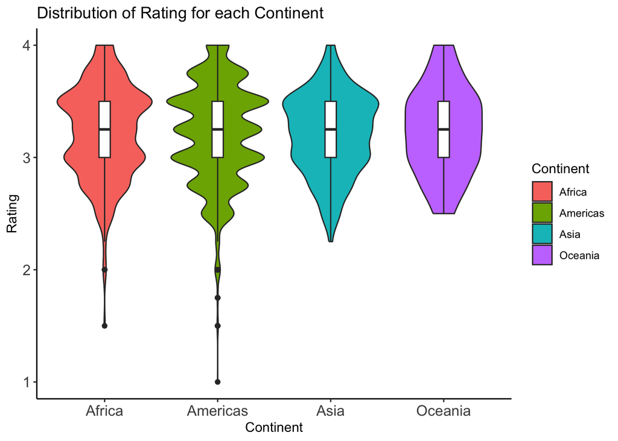

```r
# violinplots
ggplot(chocolate_over10reviews, aes(x=continent, y = rating, fill = continent)) +
  geom_violin() +
  geom_boxplot(width=0.1, fill="white") +
  labs(title="Distribution of Rating for each Continent",x="Continent", y = "Rating", fill = "Continent") +
  theme_classic() +
  theme(axis.text.x = element_text(size = 12),
        axis.text.y = element_text(size = 12))
```

Any thoughts on what you would do for this one? I think for a paper I would do this but make it black and white, but not 100% sure lol

## Part 3: Convert wide data into long data

1. Create a new set of columns titled beans, sugar, cocoa_butter, vanilla, letchin, and salt that contain a 1 or 0 representing whether or not that review for the chocolate bar contained that ingredient (1) or not (0).

```r
# new columns
# beans
chocolate$beans =  as.numeric(str_detect(chocolate$ingredients, "B"))
# sugar
chocolate$sugar =  as.numeric(str_detect(chocolate$ingredients, "S"))
# cocao_butter
chocolate$cocoa_butter =  as.numeric(str_detect(chocolate$ingredients, "C"))
# vanilla
chocolate$vanilla =  as.numeric(str_detect(chocolate$ingredients, "V"))
# letchin
chocolate$letchin =  as.numeric(str_detect(chocolate$ingredients, "L"))
# salt
chocolate$salt = as.numeric(str_detect(chocolate$ingredients, "Sa"))
```

So S* does count for finding sugar

2. Create a new set of columns titled char_cocoa, char_sweet, char_nutty, char_creamy, char_roasty, char_earthy that contain a 1 or 0 representing whether or not that the most memorable characteristic for the chocolate bar had that word (1) or not (0). For example, if the word “sweet” appears in the most_memorable_characteristics, then record a 1, otherwise a 0 for that review in the char_sweet column (Hint: check out str_detect() from the stringr package).

```r
# new columns
chocolate$char_cocoa = as.numeric(str_detect(chocolate$most_memorable_characteristics, "cocoa"))

chocolate$char_sweet = as.numeric(str_detect(chocolate$most_memorable_characteristics, "sweet"))

chocolate$char_nutty = as.numeric(str_detect(chocolate$most_memorable_characteristics, "nutty"))

chocolate$char_creamy = as.numeric(str_detect(chocolate$most_memorable_characteristics, "creamy"))

chocolate$char_roasty = as.numeric(str_detect(chocolate$most_memorable_characteristics, "roasty"))

chocolate$char_earthy = as.numeric(str_detect(chocolate$most_memorable_characteristics, "earthy"))
```

3. For each year (i.e. review_date), calculate the mean value in each new column you created across all reviews for that year. (Hint: If all has gone well thus far, you should have a dataset with 16 rows and 13 columns).

```r
# create my own mean function
mymean = function(x){
  sum(x, na.rm = TRUE) / length(x)
}

# mean of years
chocolate_means = chocolate %>%
  group_by(review_date) %>%
  summarise(across(beans:char_earthy,  mymean))
chocolate_means
```

```
## # A tibble: 16 × 13
##    review_date beans sugar cocoa_butter vanilla letchin    salt char_cocoa
##          <dbl> <dbl> <dbl>        <dbl>   <dbl>   <dbl>   <dbl>      <dbl>
##  1        2006 0.968 0.968        0.903  0.694   0.694  0           0.210
##  2        2007 0.945 0.945        0.767  0.548   0.384  0           0.342
##  3        2008 0.913 0.902        0.75   0.359   0.511  0           0.109
##  4        2009 0.919 0.919        0.772  0.325   0.341  0           0.146
##  5        2010 0.855 0.855        0.709  0.227   0.391  0.00909     0.218
##  6        2011 0.939 0.939        0.693  0.160   0.160  0.0491      0.172
##  7        2012 0.928 0.928        0.675  0.186   0.124  0.0722      0.0876
##  8        2013 0.967 0.956        0.776  0.208   0.295  0.0164      0.175
##  9        2014 0.984 0.984        0.644  0.0688  0.121  0.0324      0.0607
## 10        2015 0.986 0.979        0.546  0.0599  0.120  0           0.127
## 11        2016 0.982 0.977        0.594  0.0507  0.106  0.00922     0.0922
## 12        2017 0.981 0.981        0.562  0.0286  0.133  0.00952     0.133
## 13        2018 0.987 0.987        0.596  0.0614  0.132  0           0.180
## 14        2019 1     1            0.679  0.0259  0.202  0           0.259
## 15        2020 1     1            0.568  0.0370  0.0247 0           0.284
## 16        2021 1     0.994        0.646  0.0114  0.08   0           0.297
## # ℹ 5 more variables: char_sweet <dbl>, char_nutty <dbl>, char_creamy <dbl>,
## #   char_roasty <dbl>, char_earthy <dbl>
```

Had to create my own function to make sure NA counted towards denominator of mean but not towards sum for numerator.. not sure if there was a function for this? Couldn’t figure it out if there was

4. Convert this wide dataset into a long dataset with a new feature and mean_score column.

```r
# convert data
chocolate_means = chocolate_means %>%
  pivot_longer(-review_date, names_to = "feature", values_to = "mean_score")
chocolate_means
```

```
## # A tibble: 192 × 3
##    review_date feature      mean_score
##          <dbl> <chr>             <dbl>
##  1        2006 beans            0.968
##  2        2006 sugar            0.968
##  3        2006 cocoa_butter     0.903
##  4        2006 vanilla          0.694
##  5        2006 letchin          0.694
##  6        2006 salt             0
##  7        2006 char_cocoa       0.210
##  8        2006 char_sweet       0.161
##  9        2006 char_nutty       0.0323
## 10        2006 char_creamy      0.242
## # ℹ 182 more rows
```

Everything matches the example online!

## Part 4: Data visualization

1. An overall title for the plot and a subtitle summarizing key trends that you found. Also include a caption in the figure with your name.
2. Both the observed points for the mean_score, but also a smoothed non-linear pattern of the trend
3. All plots should be shown in the one figure
4. There should be an informative x-axis and y-axis label

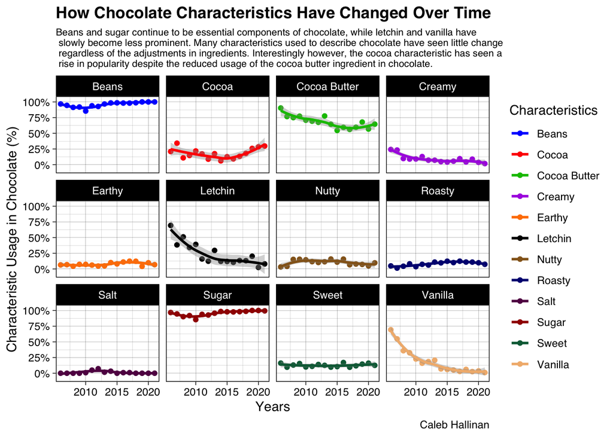

```r
# get new colors
library("paletteer")
# graph
chocolate_means %>%
  # first make new column with plot feature names
  mutate(plot_feature = str_to_title(str_replace(str_replace(feature, "char_", ""), "_", " "))) %>%
  # make ggplot object
ggplot(., aes(x = review_date, y = mean_score, color = plot_feature)) +
  # add points
  geom_point() +
  # add smooht line
  geom_smooth() +
  # labels
  labs(
        title = "How Chocolate Characteristics Have Changed Over Time",
        subtitle =
        "Beans and sugar continue to be essential components of chocolate, while letchin and vanilla have\n slowly become less prominent. Many characteristics used to describe chocolate have seen little change\n regardless of the adjustments in ingredients. Interestingly however, the cocoa characteristic has seen a\n rise in popularity despite the reduced usage of the cocoa butter ingredient in chocolate.",
        caption = "Caleb Hallinan",
        x = "Years",
        y = "Characteristic Usage in Chocolate (%)",
        color = "Characteristics"
    ) +
  # facet wrap by feature
  facet_wrap(. ~ plot_feature) +
  # change colors and add percent to y axis
    scale_colour_manual(values = paletteer_d("ggprism::colors", 12)) +
  scale_y_continuous(labels = scales::percent) +
  # for theme
  theme_linedraw() +
  theme(plot.subtitle = element_text(size=8), text = element_text(family = "sans"), plot.title = element_text(face= "bold")) +
  # get rid of gray background for legend
  guides(color=guide_legend(override.aes=list(fill=NA)))
```

Not a huge fan of the subtitle - seems difficult to format and a lot of text between title and plot. Maybe there is other functions I am missing to make it look better? Also I choose Arial (sans was what it said) font since that is most common for papers. My hope is to make the plot look professional… but I did add colors to the lines because it was fun :)

## Part 5: Make the worst plot you can!

1. Make the absolute worst plot that you can. You need to customize it in at least 7 ways to make it awful.
2. In your document, write 1 - 2 sentences about each different customization you added (using bullets – i.e. there should be at least 7 bullet points each with 1-2 sentences), and how it could be useful for you when you want to make an awesome data visualization.

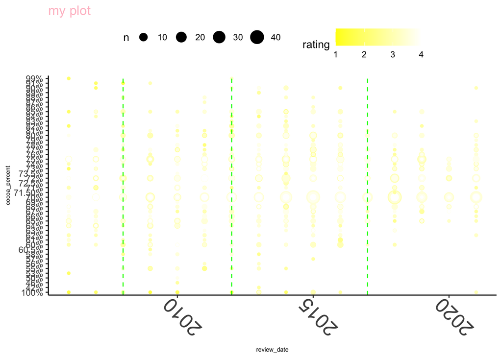

```r
# graph
ggplot(chocolate, aes(x = review_date, y = cocoa_percent, color = rating)) +
  geom_point(alpha = 1 / 10, size = 1.5) +
  labs(title = "my plot") +
  scale_color_gradient(low="yellow", high="white") +
  theme_classic()  +
  geom_count() +
  theme(legend.position = "top", axis.text.x = element_text(size = 20, angle=135), axis.title.x = element_text(size = 6),
        axis.title.y = element_text(size = 6), plot.title = element_text(color = "pink")) +
  geom_vline(xintercept = 2008, linetype = "dashed", color = "green") +
  geom_vline(xintercept = 2012, linetype = "dashed", color = "green") +
  geom_vline(xintercept = 2017, linetype = "dashed", color = "green")
```

Honestly this was tough for me to decipher and I made it! Here are the 7 ways I tried to make it awful (Also, I used numbers instead of bullets to be more clear :)):

1. The title has no meaning, is above the legend, and is randomly pink which makes it hard to see in the top left corner. In the future I would maybe bold the title, make it meaningful, center it on the figure, and make the biggest text size.
2. The x and y axis labels are both extremely small and still the variable name it has in the dataframe. Ideally these will be capitalized, have no underscore, and a normal size! Sometimes you may also need to add units to the variable to be more clear.
3. The x and y axis are messed up in different ways. The x axis is way too big, only shows three years, and is rotated 135 degrees. I’d like to see maybe every 2 years instead of 5, normal size font, and definitely not 135 degrees (90 is fine if it makes sense, but here normal would be best). The y axis is out of order, unreadable, and has the percent for every label. I’d make sure all font is readable and spaced out, and remove the % sign while adding it to the y label instead.
4. The legend and its colors are hard to read, randomly at the top, and uses odd colors. This helped me in understanding good legend position, how to change the color gradient, and the cool addition customization to the legend you can make!
5. Due to the colors being yellow, the theme_classic is not the most ideal theme to have as it makes it near impossible to see the gradient of the colors (especially the number 4). While the theme_classic is a great theme I like personally, I needed a darker theme to highlight the yellow points which I could have gotten from the theme park package we learned about in class.
6. The alpha values for the points being 1/10 is incredibly light, making it near impossible to see the 4 values. Not only that, but the size of the points are so big that they overlap with each other and block out smaller points. Changing the alpha and point size is an incredible tool due to the overlapping of points and making point size similar to text size (as in make it look realistic).
7. Instead of using the theme to have lines in the background of the plot, I used dotted green lines to show only 3 of the years present (and not even the ones on the legend). This is not ideal in the slightest, but vline/hline is a very useful function for if I wanted to separate data or could also draw segmented lines using geom_segement().

Overall, this plot isn’t really expressing anything of importance. A viewer would not know what is trying to be presented and struggle to just look at it.

## Part 6: Make my plot a better plot!

1. You need to customize it in at least 7 ways to make it better.
2. In your document, write 1 - 2 sentences about each different customization you added (using bullets – i.e. there should be at least 7 bullet points each with 1-2 sentences), describing how you improved it.

```r
# get new theme
remotes::install_github("MatthewBJane/theme_park")
```

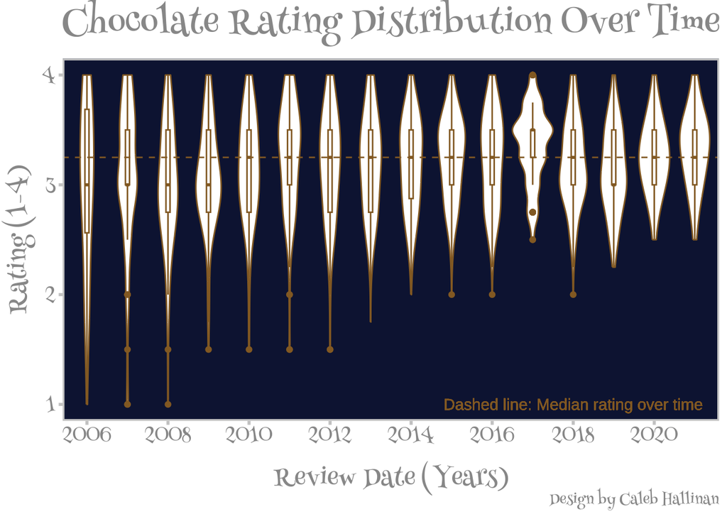

```r
library(ThemePark)


# graph
chocolate %>%
  # make object
    ggplot(aes(
        x = as.factor(review_date),
        y = rating,
        color = review_date
    )) +
  # add violinplots
    geom_violin(width = 1, adjust = 1.5) +
    labs( title = "Chocolate Rating Distribution Over Time",
          x = "Review Date (Years)",
          y = "Rating (1-4)",
          caption = "Design by Caleb Hallinan"
    ) +
  # add boxplots
    geom_boxplot(width=0.1) +
  # make colots
  scale_color_gradient(low = "#946B2D", high = "#946B2D") +
  # get rid of legend
  guides(color = "none") +
  # change text
  theme(axis.title = element_text(size = 12),
        axis.text = element_text(size = 10),
        axis.title.x = element_text(vjust = 0),
        axis.title.y = element_text(vjust = 1),
        plot.caption = element_text(size = 10)) +
  scale_x_discrete(breaks = sort(unique(chocolate$review_date))[c(TRUE, FALSE)])+
  # make ravenclaw theme
  theme_ravenclaw() +
  # add median over time
    geom_hline(yintercept = median(chocolate$rating), linetype = "dashed", color = "#946B2D") +
  # add text
  geom_text(aes(x = 13, y = 1,
                label = "Dashed line: Median rating over time"),
            stat = "unique")
```

Here are the 7 ways I made this plot better!

1. The first thing I did was create x and y labels that were not the variable names. I capitalized them while adding their units in parentheses.
2. Personally, I really like seeing the boxplots in the violin plots for the extra statistics you see (median and outliers especially). Hence, I added small boxplots inside the violin plots to better understand the distribution of the data. They are a bit small which is unfortunate, but in reality I would space out the violin plots more (which I couldn’t do without saving the figure) and make the box plots bigger.
3. I actually decided to remove the legend altogether. It only showed the review date color scheme, but that was unnecessary for the plot. Doing this made the figure larger, making the boxplots inside the violin plots look much better.
4. I added a title and caption to the plot. Now we have an informative title that explains what this plot is showing, and has my name so you know who made it!
5. The x and y tick labels were pretty small, so I increased their size while also making the x axis every 2 instead of every year. Every year made the plot a lot busier, and I don’t think making it every other hurts the readability much.
6. I added a dashed line to show the median rating over time. I thought this might help with showing how the rating changed over time.
7. Finally, I changed the theme to theme_ravenclaw! The colors are the official colors for ravenclaw and I got the theme from the “ThemePark” package. I am a ravenclaw (in Harry Potter) so I thought why not it looks kinda fun :)

I am curious if there is a better way to show this information besides violin plots? I was trying to research other ways but was unsuccessful, so hoping to see what others do for this plot!

# Print Session

```r
options(width = 120)
```